# Where in the Genome does DNA replication Begin?

### (Part B)

```python
import matplotlib.pyplot as plt
```

## Deamination

In the last section, we saw that as the replication fork expands, DNA polymerase synthesizes DNA quickly on the reverse half-strand but suffers delays on the forward half-strand. We will explore the asymmetry of DNA replication to design a new algorithm for finding ori.

How in the world can the asymmetry of replication possibly help us locate ori? Notice that since the replication of a reverse half-strand proceeds quickly, it lives double-stranded for most of its life. Conversely, a forward half-strand spends a much larger amount of its life single-stranded, waiting to be used as a template for replication. This discrepancy between the forward and reverse half-strands is important because single-stranded DNA has a much higher mutation rate than double-stranded DNA. In particular, if one of the four nucleotides in single-stranded DNA has a greater tendency than other nucleotides to mutate in single-stranded DNA, then we should observe a shortage of this nucleotide on the forward half-strand.

Following up on this thought, let’s compare the nucleotide counts of the reverse and forward half-strands. If these counts differ substantially, then we will design an algorithm that attempts to track down these differences in genomes for which ori is unknown. The nucleotide counts for Thermotoga petrophila are shown in the figure below.

[figure not shown]

**Counting nucleotides in the Thermotoga petrophila genome on the forward and reverse half-strands.**

Although the frequencies of A and T are practically identical on the two half-strands, C is more frequent on the reverse half-strand than on the forward half-strand. Its complementary nucleotide G is less frequent on the reverse half-strand than on the forward half-strand.

It turns out that we observe these discrepancies because cytosine (C) has a tendency to mutate into thymine (T) through a process called deamination. Deamination rates rise 100-fold when DNA is single-stranded, which leads to a decrease in cytosine on the forward half-strand, thus forming mismatched base pairs T-G. These mismatched pairs can further mutate into T-A pairs when the bond is repaired in the next round of replication, which accounts for the observed decrease in guanine (G) on the reverse half-strand (recall that a forward parent half-strand synthesizes a reverse daughter half-strand, and vice-versa).

### Analyzing a genome’s half-strands

Although most bacteria have circular genomes, we have thus far assumed that genomes were linear, a reasonable simplifying assumption because the length of the window is much shorter than the length of the genome. This time, because we are sliding a giant window, we should account for windows that “wrap around” the end of Genome. To do so, we will define a string ExtendedGenome as Genome+Genome[0:n//2]. That is, we copy the first len(Genome)//2 nucleotides of Genome to the end of the string

We will keep track of the total number of occurrences of C that we encounter in each window of ExtendedGenome by using a symbol array. The i-th element of the symbol array is equal to the number of occurrences of the symbol in the window of length len(Genome)//2 starting at position i of ExtendedGenome.

```python
def PatternCount(Pattern, Text):
    count = 0
    for i in range(len(Text)-len(Pattern)+1):
        if Text[i:i+len(Pattern)] == Pattern:
            count = count+1
    return count
```

```python
def inefficient_SymbolArray(Genome, symbol):
    """Returns a dictionary containing the total number of occurrences
    of symbol iin each window of ExtendedGenome. The i-th element of
    the symbol array is equal to the number of occurrences of the
    symbol in the window of length len(Genome)//2 starting at
    position i of ExtendedGenome."""
    array = {}
    n = len(Genome)
    ExtendedGenome = Genome + Genome[0:n//2]
    for i in range(n):
        array[i] = PatternCount(symbol, ExtendedGenome[i:i+(n//2)])
    return array
```

```python
inefficient_SymbolArray(Genome="AAAAGGGG", symbol="A")
```

```
{0: 4, 1: 3, 2: 2, 3: 1, 4: 0, 5: 1, 6: 2, 7: 3}
```

```python
def FasterSymbolArray(Genome, symbol):
    """Returns a dictionary containing the total number of occurrences
    of symbol iin each window of ExtendedGenome. The i-th element of
    the symbol array is equal to the number of occurrences of the
    symbol in the window of length len(Genome)//2 starting at
    position i of ExtendedGenome."""
    array = {}
    n = len(Genome)
    ExtendedGenome = Genome + Genome[0:n//2]

    # look at the first half of Genome to compute first array value
    array[0] = PatternCount(symbol, Genome[0:n//2])

    for i in range(1, n):
        # start by setting the current array value equal to the previous array value
        array[i] = array[i-1]
        # the current array value can differ from the previous array value by at most 1
        if ExtendedGenome[i-1] == symbol:
            array[i] = array[i]-1
        if ExtendedGenome[i+(n//2)-1] == symbol:
            array[i] = array[i]+1
    return array
```

```python
FasterSymbolArray(Genome="AAAAGGGG", symbol="A")
```

```
{0: 4, 1: 3, 2: 2, 3: 1, 4: 0, 5: 1, 6: 2, 7: 3}
```

#### Running SymbolArray with Genome equal to the E. coli genome and symbol equal to "C"

```python
with open("../media/E_coli_genome.txt", 'r') as fin:
    e_coli_gnome = fin.read()
```

```python
pos_count = FasterSymbolArray(Genome=e_coli_gnome, symbol="C")
```

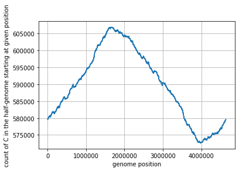

```python
fig, ax = plt.subplots()
ax.plot(range(len(pos_count)), list(pos_count.values()))

ax.set(xlabel='genome position', ylabel='count of C in the half-genome starting at given position')
ax.grid()

plt.show()
```

The figure below visualizes the symbol array for E. coli and symbol equal to "C". Notice the clear pattern in the data! The maximum value of the array occurs around position 1600000, and the minimum value of the array occurs around position 4000000. We can therefore infer that the reverse half-strand begins around position 1600000, and that the forward half-strand begins around position 4000000. Because we know that ori occurs where the reverse half-strand transitions to the forward half-strand, we have discovered that ori is located in the neighborhood of position 4000000 of the E. coli genome, without ever needing to put on a lab coat!

In practice, scientists use a more accurate approach that accounts for both G and C when searching for ori.

### The Skew diagram

Thus, our idea is to traverse the genome, keeping a running total of the difference between the counts of G and C. If this difference starts increasing, then we guess that we are on the forward half-strand; on the other hand, if this difference starts decreasing, then we guess that we are on the reverse half-strand (see figure below).

[figure not shown]

**Because of deamination, each forward half-strand has more guanine than cytosine, and each reverse half-strand has more cytosine than guanine. The difference between the counts of G and C is therefore positive on the forward half-strand and negative on the reverse half-strand.**

We will keep track of the difference between the total number of occurrences of G and the total number of occurrences of C that we have encountered so far in Genome by using a skew array. This array, denoted Skew, is defined by setting Skew[i] equal to the number of occurrences of G minus the number of occurrences of C in the first i nucleotides of Genome (see figure below). We also set Skew[0] equal to zero.

[figure not shown]

Given a string Genome, we can form its skew array by setting Skew[0] equal to 0, and then ranging through the genome. At position i of Genome, if we encounter an A or a T, we set Skew[i+1] equal to Skew[i]; if we encounter a G, we set Skew[i+1] equal to Skew[i]+1; if we encounter a C, we set Skew[i+1] equal to Skew[i]-1. **The skew increases when we encounter G and decreases when we encounter C.**

```python
def SkewArray(Genome):
    """Returns the skew array of Genome in the form of a list whose
    i-th element is Skew[i]. Takes a DNA string Genome as input

    The skew array is conformed by keeping track of the difference
    between the total number of occurrences of G minus the total number
    of occurrences of C  in the first i nucleotides of Genome"""
    Skew = [0]
    n = len(Genome)
    for i in range(n):
        # start by setting the current array value equal to the previous array value
        Skew.append(Skew[-1])
        # the current array value can differ from the previous array value by at most 1
        if Genome[i] == 'G':
            Skew[-1] += 1
        if Genome[i] == 'C':
            Skew[-1] -= 1
    return Skew
```

```python
Skew = SkewArray("CATGGGCATCGGCCATACGCC")
Skew
```

```
[0, -1, -1, -1, 0, 1, 2, 1, 1, 1, 0, 1, 2, 1, 0, 0, 0, 0, -1, 0, -1, -2]
```

#### Creating the skew diagram of E. coli genome

```python
with open("../media/E_coli_genome.txt", 'r') as fin:
    e_coli_gnome = fin.read()
```

```python
e_coli_skew = SkewArray(Genome=e_coli_gnome)
```

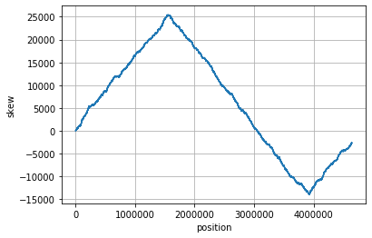

```python
fig, ax = plt.subplots()
ax.plot(range(len(e_coli_skew)), e_coli_skew)

ax.set(xlabel='position', ylabel='skew')
ax.grid()

plt.show()
```

The previous figure depicts the skew diagram for a linearized E. coli genome. The pattern is even stronger than the pattern observed when we visualized the symbol array! It turns out that the skew diagram for many bacterial genomes has a similar characteristic shape.

**The skew diagram for E. coli achieves a maximum and minimum at positions 1550413 and 3923620, respectively.**

**Minimum Skew Problem:** Find a position in a genome where the skew diagram attains a minimum.

- **Input:** A DNA string Genome.
- **Output:** All integer(s) i minimizing Skew[i] among all values of i (from 0 to len(Genome)).

```python
def MinimumSkew(Genome):
    # generate an empty list positions
    positions = []
    # set a variable equal to SkewArray(Genome)
    skew = SkewArray(Genome)
    # find the minimum value of all values in the skew array
    min_val = min(skew)
    # range over the length of the skew array and add all positions achieving the min to positions
    for i in range(len(Genome)):
        if skew[i] == min_val:
            positions.append(i)
    return positions
```

#### Testing MinimumSkew

```python
test_g = "TAAAGACTGCCGAGAGGCCAACACGAGTGCTAGAACGAGGGGCGTAAACGCGGGTCCGAT"
```

```python
MinimumSkew(Genome=test_g)
```

```
[11, 24]
```

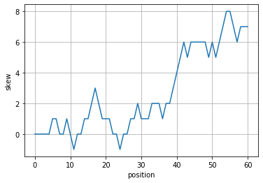

```python
tsa = SkewArray(Genome=test_g)

fig, ax = plt.subplots()
ax.plot(range(len(tsa)), tsa)

ax.set(xlabel='position', ylabel='skew')
ax.grid()

plt.show()
```

## Hamming Distance Problem

We say that position i in k-mers p and q is a **mismatch** if the symbols at position i of the two strings are not the same. The **total number of mismatches** between strings p and q is called the **Hamming distance** between these strings.

**Hamming Distance Problem:** Compute the Hamming distance between two strings.

- **Input:** Two strings of equal length.
- **Output:** The Hamming distance between these strings.

```python
def HammingDistance(p, q):
    """Returns Hamming distance between p and q"""
    distance = 0
    for i, j in zip(p, q):
        if i != j:
            distance +=1
    return distance
```

```python
HammingDistance("GGGCCGTTGGT", "GGACCGTTGAC")
```

```
3
```

### Approximate Pattern Matching Problem

We say that a k-mer Pattern appears as a substring of Text with at most d mismatches if there is some k-mer substring Pattern' of Text having d or fewer mismatches with Pattern; that is, HammingDistance(Pattern, Pattern') ≤ d. Our observation that a DnaA box may appear with slight variations leads to the following generalization of the Pattern Matching Problem.

**Approximate Pattern Matching Problem:** Find all approximate occurrences of a pattern in a string.

- **Input:** Strings Pattern and Text along with an integer d.
- **Output:** All starting positions where Pattern appears as a substring of Text with at most d mismatches.

```python
def ApproximatePatternMatching(Text, Pattern, d):
    """Returns a list with all starting positions where Pattern
    appears as a substring of Text with at most d mismatches."""
    positions = []
    for i in range(len(Text)-len(Pattern)+1):
        if HammingDistance(Text[i:i+len(Pattern)], Pattern) <= d:
            positions.append(i)
    return positions
```

```python
ApproximatePatternMatching(Text="CGCCCGAATCCAGAACGCATTCCCATATTTCGGGACCACTGGCCTCCACGGTACGGACGTCAATCAAAT",
                           Pattern="ATTCTGGA", d=3)
```

```
[6, 7, 26, 27]
```

#### ApproximatePatternCount

Our goal now is to modify our previous algorithm for the Frequent Words Problem in order to find DnaA boxes by identifying frequent k-mers, possibly with mismatches. Given input strings Text and Pattern as well as an integer d, we extend the definition of PatternCount to the function ApproximatePatternCount(Pattern, Text, d). This function computes the number of occurrences of Pattern in Text with at most d mismatches.

```python
def ApproximatePatternCount(Text, Pattern, d):
    """Computes the number of occurrences of Pattern in Text
    with at most d mismatches"""
    count = 0
    for i in range(len(Text)-len(Pattern)+1):
        if HammingDistance(Text[i:i+len(Pattern)], Pattern) <= d:
            count += 1
    return count
```

```python
ApproximatePatternCount(Text="TTTAGAGCCTTCAGAGG",
                        Pattern="GAGG", d=2)
```

```
4
```

We now make a final attempt to find DnaA boxes in the region of the E. coli genome hypothesized by the minimum skew as ori. Although the minimum of the skew diagram for E. coli is found at position 3923620, we should not assume that its ori is found exactly at this position due to random fluctuations in the skew. To remedy this issue, we could choose a larger window size (e.g., 1000), but expanding the window introduces the risk that we may bring in other clumped 9-mers that do not represent DnaA boxes but appear in this window more often than the true DnaA box. It makes more sense to try a small window either starting, ending, or centered at the position of minimum skew.

Let’s cross our fingers and identify the most frequent 9-mers (with 1 mismatch) within a window of length 500 starting at position 3923620 of the E. coli genome. Bingo! The experimentally confirmed DnaA box in E. coli (**TTATCCACA**) is indeed a most frequent 9-mer, along with its reverse complement **TGTGGATAA** (with 1 mismatch):

[figure not shown]

You will notice that we highlighted an interior interval of this sequence with darker text. This region is the experimentally verified ori of E. coli, which starts 37 nucleotides after position 3923620, where the skew reaches its minimum value.

We were very fortunate that the DnaA boxes of E. coli are captured in the window that we chose. Moreover, while TTATCCACA represents a most frequent 9-mer in this 500-nucleotide window, it is not the only one: GGATCCTGG, GATCCCAGC, GTTATCCAC, AGCTGGGAT, and CTGGGATCA (along with their reverse complements) also appear four times with 1 mismatch.

We do not know what purpose — if any — these other 9-mers serve in the E. coli genome, but we do know that there are many different types of hidden messages in genomes; these hidden messages have a tendency to cluster within a genome, and most of them have nothing to do with replication. **The important lesson is that existing approaches to ori prediction remain imperfect and sometimes inconclusive. However, even providing biologists with a small collection of 9-mers as candidate DnaA boxes is a great aid as long as one of these 9-mers is correct**.

Thus, the moral of this chapter is that even though computational analysis can be powerful, bioinformaticians should collaborate with biologists to verify their predictions.

## Methods summary

```python
def PatternCount(Pattern, Text):
    count = 0
    for i in range(len(Text)-len(Pattern)+1):
        if Text[i:i+len(Pattern)] == Pattern:
            count = count+1
    return count

def FasterSymbolArray(Genome, symbol):
    """Returns a dictionary containing the total number of occurrences
    of symbol iin each window of ExtendedGenome. The i-th element of
    the symbol array is equal to the number of occurrences of the
    symbol in the window of length len(Genome)//2 starting at
    position i of ExtendedGenome."""
    array = {}
    n = len(Genome)
    ExtendedGenome = Genome + Genome[0:n//2]

    # look at the first half of Genome to compute first array value
    array[0] = PatternCount(symbol, Genome[0:n//2])

    for i in range(1, n):
        # start by setting the current array value equal to the previous array value
        array[i] = array[i-1]
        # the current array value can differ from the previous array value by at most 1
        if ExtendedGenome[i-1] == symbol:
            array[i] = array[i]-1
        if ExtendedGenome[i+(n//2)-1] == symbol:
            array[i] = array[i]+1
    return array
```

```python
def SkewArray(Genome):
    """Returns the skew array of Genome in the form of a list whose
    i-th element is Skew[i]. Takes a DNA string Genome as input

    The skew array is conformed by keeping track of the difference
    between the total number of occurrences of G minus the total number
    of occurrences of C  in the first i nucleotides of Genome"""
    Skew = [0]
    n = len(Genome)
    for i in range(n):
        # start by setting the current array value equal to the previous array value
        Skew.append(Skew[-1])
        # the current array value can differ from the previous array value by at most 1
        if Genome[i] == 'G':
            Skew[-1] += 1
        if Genome[i] == 'C':
            Skew[-1] -= 1
    return Skew

def MinimumSkew(Genome):
    # generate an empty list positions
    positions = []
    # set a variable equal to SkewArray(Genome)
    skew = SkewArray(Genome)
    # find the minimum value of all values in the skew array
    min_val = min(skew)
    # range over the length of the skew array and add all positions achieving the min to positions
    for i in range(len(Genome)):
        if skew[i] == min_val:
            positions.append(i)
    return positions
```

```python
def HammingDistance(p, q):
    """Returns Hamming distance between p and q"""
    distance = 0
    for i, j in zip(p, q):
        if i != j:
            distance +=1
    return distance
```

```python
def ApproximatePatternMatching(Text, Pattern, d):
    """Returns a list with all starting positions where Pattern
    appears as a substring of Text with at most d mismatches."""
    positions = []
    for i in range(len(Text)-len(Pattern)+1):
        if HammingDistance(Text[i:i+len(Pattern)], Pattern) <= d:
            positions.append(i)
    return positions
```

```python
def ApproximatePatternCount(Text, Pattern, d):
    """Computes the number of occurrences of Pattern in Text
    with at most d mismatches"""
    count = 0
    for i in range(len(Text)-len(Pattern)+1):
        if HammingDistance(Text[i:i+len(Pattern)], Pattern) <= d:
            count += 1
    return count
```